# Bayesian Evidence Synthesis

21-09-2020

## Replication

Repetition increases the perceived truth equally for plausible and implausible statements (Fazio, Rand, & Pennycook, 2019)

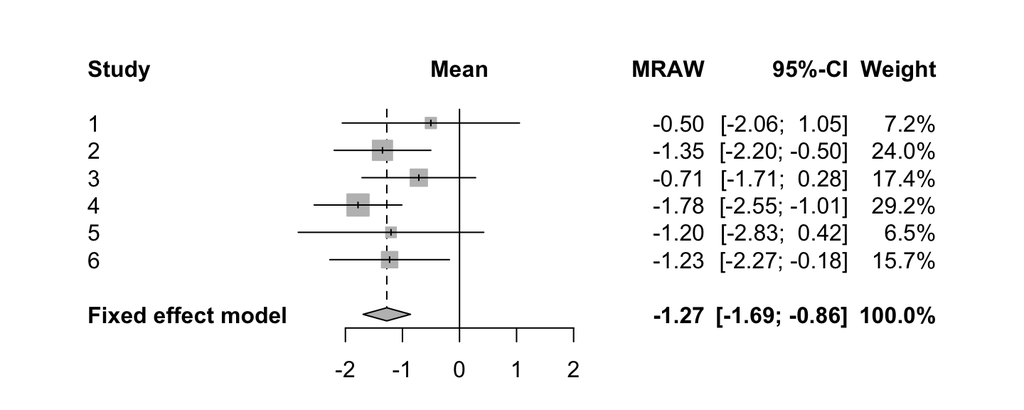

Replication is nice, but not enough.

## Conceptual replications

- If a study is methodologically flawed, all direct replications will inherently exploit the flaws.
- Conceptual replications try to address a single problem from different angles.
  - Different methodologies
  - Different operationalizations
- But how should we combine multiple studies with varying designs?

## Bayesian Evidence Synthesis

Instead of addressing the parameter estimates, Bayesian Evidence Synthesis expresses the support for a given hypothesis in terms of a Bayes Factor (Kuiper, Buskens, Raub, & Hoijtink, 2013).

1. Construct study-specific hypotheses that incorporate the models and operationalizations at hand.
2. Express the support for the study specific hypotheses in terms of a Bayes Factor.
3. Combine the study-specific Bayes Factors by means of multiplication into one overall measure of evidence.

## Proposal

In general conditions, Bayesian Evidence Synthesis proved to work.

However, study-specific Bayes Factors depend on the fit and the complexity.

- How to handle hypotheses with varying dimensions?
- Can we incorporate underpowered studies?
- How to handle situations in which the sample sizes differ dramatically over the studies?

## Specifically

Simulations with multiple statistical models (e.g., linear, logit, probit and/or Poisson regression).

Vary:

- Sample sizes
- Number of parameters in the hypotheses
- Effect sizes
- Equality / inequality constrained hypotheses

Evaluate:

- True hypothesis rate

## References

Fazio, L. K., Rand, D. G., & Pennycook, G. (2019). Repetition increases perceived truth equally for plausible and implausible statements. *Psychonomic Bulletin & Review*, *26*(5), 1705–1710.

Kuiper, R. M., Buskens, V., Raub, W., & Hoijtink, H. (2013). Combining statistical evidence from several studies: A method using bayesian updating and an example from research on trust problems in social and economic exchange. *Sociological Methods & Research*, *42*(1), 60–81.